# Final Project: NICU Dataset

Kevin Black

2022-12-06

## **This project is an exploratory analysis of a NICU dataset.**

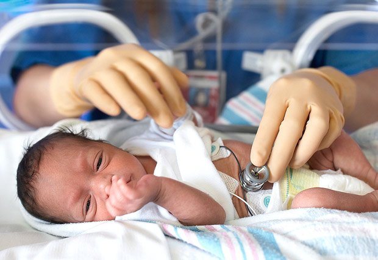

### **Introduction:**

##### In our initial exploration of this dataset, we can see that it contains information on 25 different NICU patients over the course of 10 different timepoints. We can also see that this the dataset contains 348 columns with different variables. However, we have added an extra column containing the total number of days stayed in the nicu. We did this by subtracting the delivery date from the discharge date. There is a slight chance of error here, as it is possible for babies to spend some time in the newborn nursery before being transferred to the NICU. However, this timespan is typically less than 3 days, so any error should be very minimal.

##### As someone very familiar with the NICU setting, I immediately found certain variables that I wanted to investigate further. A few of these variables included NEC, which stands for Necrotizing Enterocolitis, an infection of the bowels that can prove fatal if not detected early on. I have read research papers relating this disorder to low birthweight, low gestational age, birth trauma, and the use of formula over breastmilk early on. Unfortunately, upon further investigation, it was found that only 2 of the 25 patients were diagnosed with NEC, so there was not enough of a sample to delve deeper into this area. I was also hoping that the data would show at what time point NEC developed in these two patients. However, this information was not provided.

##### There were other variables that followed this same pattern of not containing enough samples to investigate further. Some examples were advanced maternal age, whether the mother used any drugs or alcohol during pregnancy, and whether the child had developmental delays.

### **Exploratory Data Analysis:**

##### After learning more about the dataset, I decided to pick out a handful of variables that didn’t contain many missing values. I then converted these variables to a numeric format and placed them into a PCA plot to better visualize their relationships with one another. The PCA plot can be seen below:

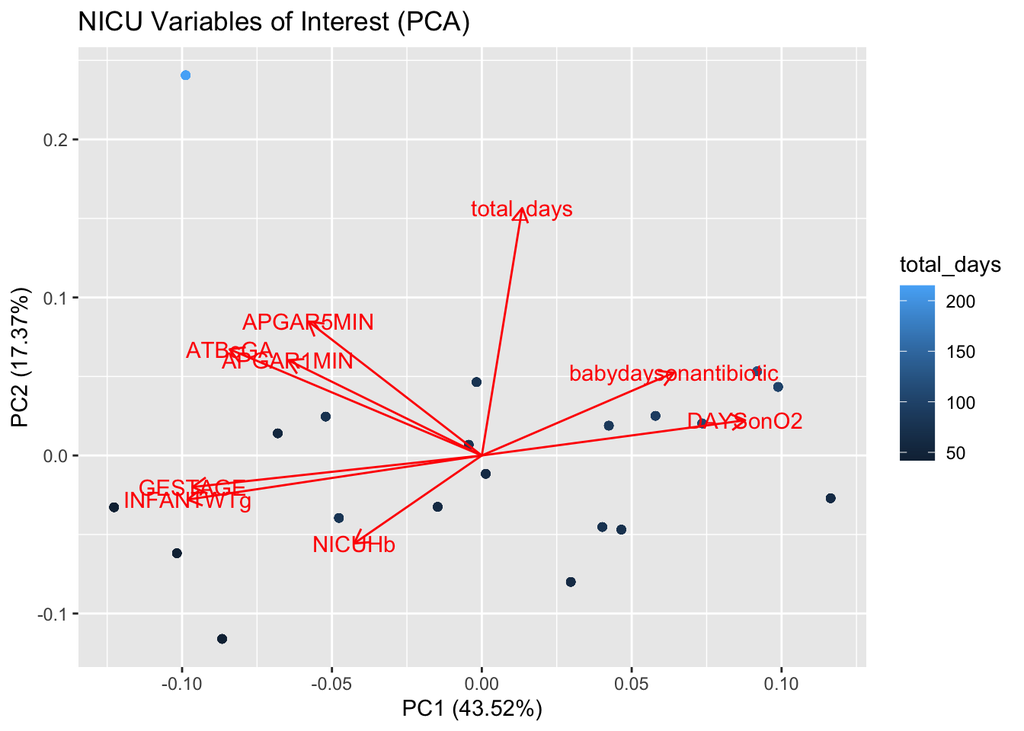

##### From this plot, we’re able to visualize a few different relationships that may be worth investigating further. For example, there seems to be a a positive relationship between days on antibiotics and days on oxygen. In addition, there appears to be an inverse relationship between the number of days on oxygen and both gestational age and weight. And finally, one of the more interesting relationships appears in the form of an inverse relationship between the number of days on antibiotics and hemoglobin levels. Now that we can visualize these relationships, it is time to perform some hypothesis tests.

### **Hypothesis Testing:**

##### We can now perform hypothesis testing. The three hypotheses that we will be testing are as follows:

##### 1.) As infant weight increases, days on oxygen will decrease.

##### 2.) As hemoglobin increases, days on antibiotics will decrease.

##### 3.) As hemoglobin increases, total days spent in the NICU will decrease.

**Hypothesis #1: As Infant Weight increases, Days on Oxygen will decrease.**

```
##
##  Pearson's product-moment correlation
##
## data:  nicu$INFANTWTg and nicu$DAYSonO2
## t = -16.618, df = 248, p-value < 2.2e-16
## alternative hypothesis: true correlation is not equal to 0
## 95 percent confidence interval:
##  -0.7797003 -0.6613372
## sample estimates:
##        cor
## -0.7258483
```

```
##
##  Spearman's rank correlation rho
##
## data:  nicu$INFANTWTg and nicu$DAYSonO2
## S = 4497260, p-value < 2.2e-16
## alternative hypothesis: true rho is not equal to 0
## sample estimates:
##        rho
## -0.7269754
```

```
## confidence interval
##       2.5 %     97.5 %
##  -0.8033692 -0.6505238
## sample estimate
##  -0.7269754
```

```
##
##  Pearson's Chi-squared test with simulated p-value (based on 2000
##  replicates)
##
## data:  table(nicu$INFANTWTg, nicu$DAYSonO2)
## X-squared = 4062.5, df = NA, p-value = 0.0004998
```

##### Here, we ran a few different correlation tests, including a pearson correlation test, a spearman’s rank correlation test with confidence intervals, and a chi-squared test. We are mainly focusing in on our p-values and our confidence intervals. In this case, the p-values are below 0.05 and our confidence intervals do not contain zero. This indicates that the relationship between these two variables is significant.

**Hypothesis #2: As Hemoglobin levels increase, Days on Antibiotics will decrease.**

```
##
##  Pearson's product-moment correlation
##
## data:  nicu$NICUHb and nicu$babydaysonantibiotic
## t = -3.8485, df = 248, p-value = 0.0001512
## alternative hypothesis: true correlation is not equal to 0
## 95 percent confidence interval:
##  -0.3511215 -0.1167682
## sample estimates:
##        cor
## -0.2373961
```

```
##
##  Spearman's rank correlation rho
##
## data:  nicu$NICUHb and nicu$babydaysonantibiotic
## S = 3577305, p-value = 1.049e-09
## alternative hypothesis: true rho is not equal to 0
## sample estimates:
##       rho
## -0.373707
```

```
## confidence interval
##       2.5 %     97.5 %
##  -0.5005892 -0.2467987
## sample estimate
##  -0.373707
```

```
##
##  Pearson's Chi-squared test with simulated p-value (based on 2000
##  replicates)
##
## data:  table(nicu$NICUHb, nicu$babydaysonantibiotic)
## X-squared = 755.21, df = NA, p-value = 0.0004998
```

##### For this hypothesis, we found that we had some NA values in the Days on Antibiotics column. For this variable, we changed all NA values to zero in order to calculate our spearman confidence intervals.

**Hypothesis #3: As Hemoglobin levels increase, Total Days spent in the NICU will decrease.**

```
##
##  Pearson's product-moment correlation
##
## data:  nicu$NICUHb and nicu$total_days
## t = -3.3435, df = 248, p-value = 0.0009551
## alternative hypothesis: true correlation is not equal to 0
## 95 percent confidence interval:
##  -0.32341882 -0.08582988
## sample estimates:
##        cor
## -0.2076853
```

```
##
##  Spearman's rank correlation rho
##
## data:  nicu$NICUHb and nicu$total_days
## S = 3391568, p-value = 1.107e-06
## alternative hypothesis: true rho is not equal to 0
## sample estimates:
##        rho
## -0.3023829
```

```
## confidence interval
##       2.5 %     97.5 %
##  -0.4453631 -0.1593785
## sample estimate
##  -0.3023829
```

```
##
##  Pearson's Chi-squared test with simulated p-value (based on 2000
##  replicates)
##
## data:  table(nicu$NICUHb, nicu$total_days)
## X-squared = 1402.1, df = NA, p-value = 0.0004998
```

##### As we can see, each of these hypothesis tests have proven to be significant. In each of our three hypotheses, the p-values are well below 0.05. In addition, our 95% confidence intervals in each test do not contain zero. Therefore, we can reject the null hypothesis and assume that these relationships are significant. Next, we will perform the final step in our analysis and create linear regressions for each of our three hypotheses.

### **Linear Regressions:**

##### Model for Hypothesis #1:

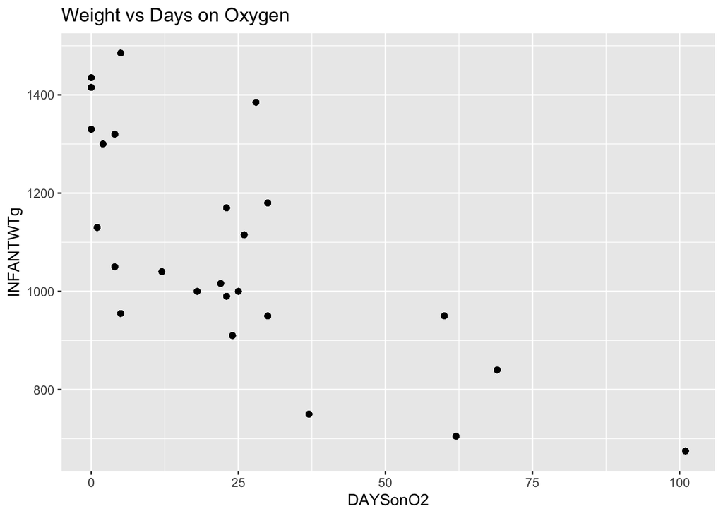

```
##
## Call:
## lm(formula = INFANTWTg ~ DAYSonO2, data = nicu)
##
## Residuals:
##     Min      1Q  Median      3Q     Max
## -256.59 -125.59   41.41   99.84  324.55
##
## Coefficients:
##              Estimate Std. Error t value Pr(>|t|)
## (Intercept) 1244.4428    13.7742   90.35   <2e-16 ***
## DAYSonO2      -6.5713     0.3954  -16.62   <2e-16 ***
## ---
## Signif. codes:  0 '***' 0.001 '**' 0.01 '*' 0.05 '.' 0.1 ' ' 1
##
## Residual standard error: 155.2 on 248 degrees of freedom
## Multiple R-squared:  0.5269, Adjusted R-squared:  0.5249
## F-statistic: 276.2 on 1 and 248 DF,  p-value: < 2.2e-16
```

```
## (Intercept)    DAYSonO2
## 1244.442840   -6.571311
```

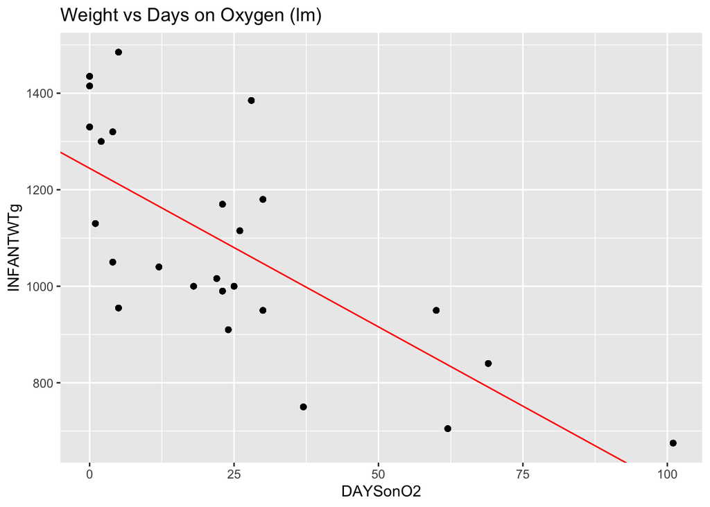

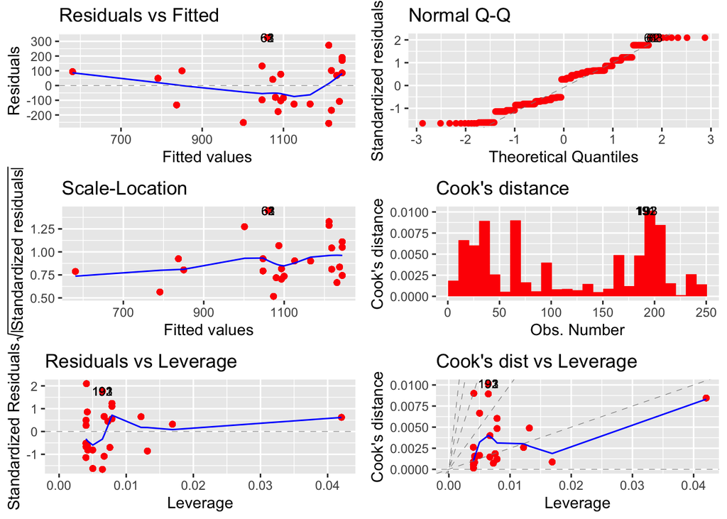

##### We can also perform a bootstrap on our linear model to see if the results change.

```r
tc <- trainControl(method = "boot",
                   number = 999)
model1_boot <- train(INFANTWTg ~ DAYSonO2,
           data = nicu,
           method = "lm",
           trControl = tc)

model1_boot
```

```
## Linear Regression
##
## 250 samples
##   1 predictor
##
## No pre-processing
## Resampling: Bootstrapped (999 reps)
## Summary of sample sizes: 250, 250, 250, 250, 250, 250, ...
## Resampling results:
##
##   RMSE      Rsquared   MAE
##   155.4546  0.5273551  137.3137
##
## Tuning parameter 'intercept' was held constant at a value of TRUE
```

##### Model for Hypothesis #2:

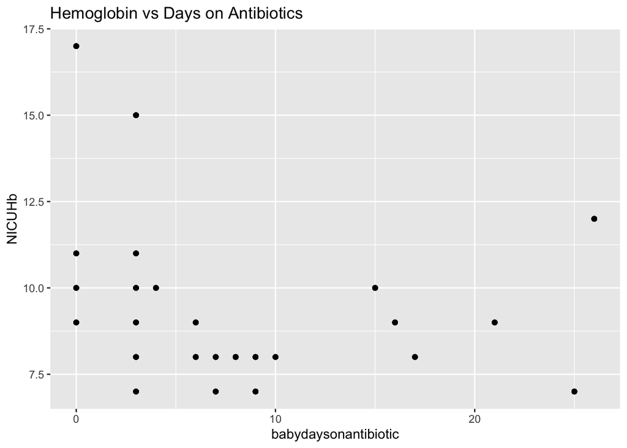

```
##
## Call:
## lm(formula = NICUHb ~ babydaysonantibiotic, data = nicu)
##
## Residuals:
##     Min      1Q  Median      3Q     Max
## -2.7855 -1.4120 -0.7395  0.5593  6.9903
##
## Coefficients:
##                      Estimate Std. Error t value Pr(>|t|)
## (Intercept)          10.00968    0.21542  46.467  < 2e-16 ***
## babydaysonantibiotic -0.07472    0.01941  -3.849 0.000151 ***
## ---
## Signif. codes:  0 '***' 0.001 '**' 0.01 '*' 0.05 '.' 0.1 ' ' 1
##
## Residual standard error: 2.308 on 248 degrees of freedom
## Multiple R-squared:  0.05636,    Adjusted R-squared:  0.05255
## F-statistic: 14.81 on 1 and 248 DF,  p-value: 0.0001512
```

```
##          (Intercept) babydaysonantibiotic
##          10.00967906          -0.07471557
```

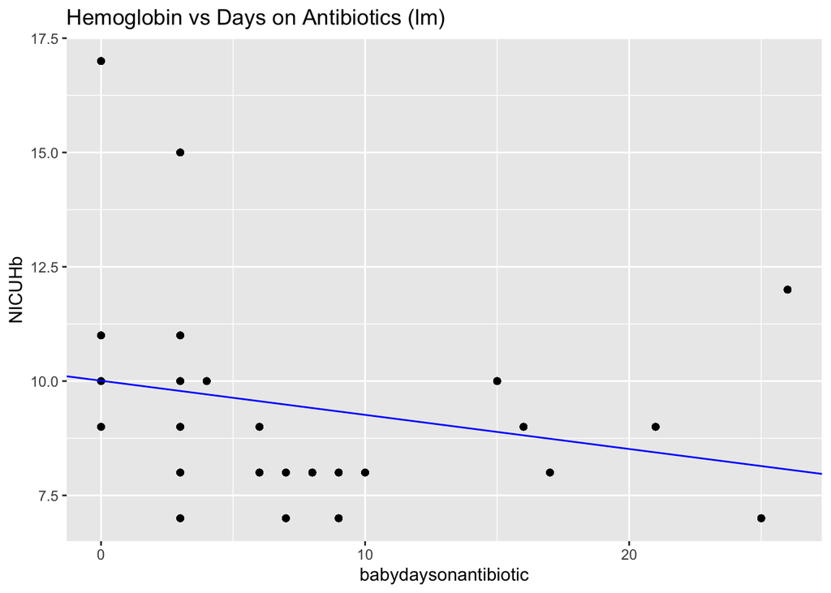

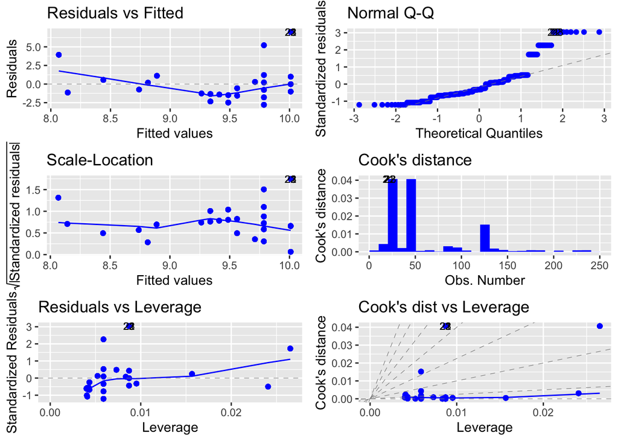

```r
tc <- trainControl(method = "boot",
                   number = 999)
model2_boot <- train(babydaysonantibiotic ~ NICUHb,
           data = nicu,
           method = "lm",
           trControl = tc)

model2_boot
```

```
## Linear Regression
##
## 250 samples
##   1 predictor
##
## No pre-processing
## Resampling: Bootstrapped (999 reps)
## Summary of sample sizes: 250, 250, 250, 250, 250, 250, ...
## Resampling results:
##
##   RMSE      Rsquared    MAE
##   7.338041  0.06159802  5.693212
##
## Tuning parameter 'intercept' was held constant at a value of TRUE
```

##### Model for Hypothesis #3:

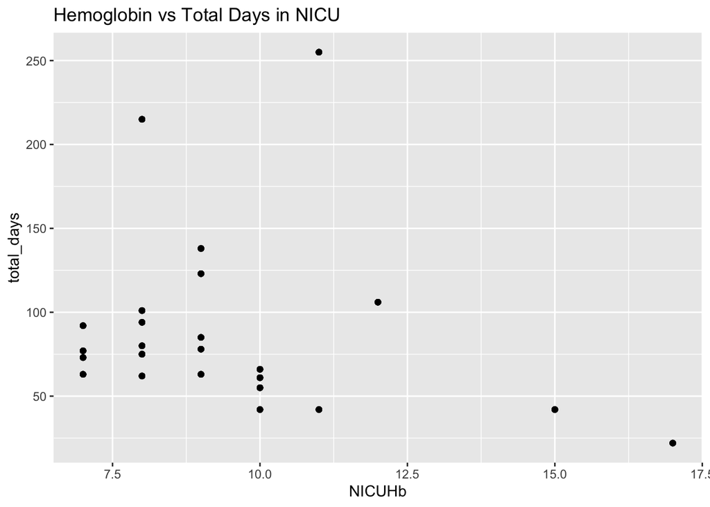

```
##
## Call:
## lm(formula = total_days ~ NICUHb, data = nicu)
##
## Residuals:
##    Min     1Q Median     3Q    Max
## -42.73 -26.18 -18.62   0.38 174.71
##
## Coefficients:
##             Estimate Std. Error t value Pr(>|t|)
## (Intercept)  129.163     12.880  10.028  < 2e-16 ***
## NICUHb        -4.443      1.329  -3.344 0.000955 ***
## ---
## Signif. codes:  0 '***' 0.001 '**' 0.01 '*' 0.05 '.' 0.1 ' ' 1
##
## Residual standard error: 49.72 on 248 degrees of freedom
## Multiple R-squared:  0.04313,    Adjusted R-squared:  0.03927
## F-statistic: 11.18 on 1 and 248 DF,  p-value: 0.0009551
```

```
## (Intercept)      NICUHb
##  129.162857   -4.442857
```

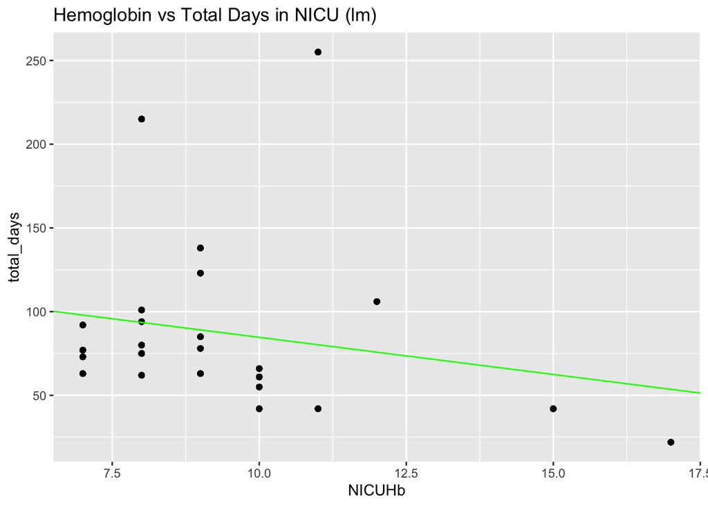

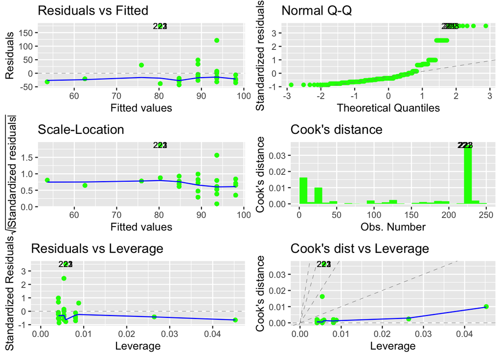

```r
tc <- trainControl(method = "boot",
                   number = 999)
model3_boot <- train(NICUHb ~ total_days,
           data = nicu,
           method = "lm",
           trControl = tc)

model3_boot
```

```
## Linear Regression
##
## 250 samples
##   1 predictor
##
## No pre-processing
## Resampling: Bootstrapped (999 reps)
## Summary of sample sizes: 250, 250, 250, 250, 250, 250, ...
## Resampling results:
##
##   RMSE      Rsquared   MAE
##   2.334009  0.0494735  1.675672
##
## Tuning parameter 'intercept' was held constant at a value of TRUE
```

##### In our final model, we can see that bootstrapping only increased our r-squared variable slightly, from 0.043 to 0.05.

### **Conclusion:**

##### In the end, although some of our models appeared to be better fitting than others, it is clear that the three relationships that we investigated were significant. In order to get started with this dataset, we had to deal with some missing values, create a new column with a newly calculated variable, and search through nearly 350 variables to select a few of interest. We then created a pca biplot of these variables of interest, in order to visualize various relationships to focus on. After choosing three of these relationships, we formed a series of hypotheses and tested them through various correlation tests. Finally, we performed a series of linear regressions in order to fit our data.

##### Since there were only 25 patients in this dataset, larger sample sizes will be needed to further explore the correlations we found. However, this additional research is worthwhile because these relationships may prove useful when applied to healthcare in the real world. One example of this is that, if higher hemoglobin levels truly do help to decrease both length of stay and the number of days on antibiotics, finding ways to increase and stabilize hemoglobin levels in babies could prove beneficial for both the patient and the hospital. In addition, if increases in birth weight help decrease the number of days on oxygen, it may give providers a more accurate predicition of a patient’s supplmental oxygen therapy timeline. It may also be the start of helping providers decide whether birth weight or gestational age are more important when assessing a patient’s milestones and delays.

##### The relationships that we explored in this analysis are only the tip of the iceberg. This dataset is vast and there are still many more variables to delve into and investigate further. We were able to stumble upon some significant findings with just a fraction of this dataset. I have no doubts that further exploration will bring about even more interesting findings that can be used to improve the field of healthcare.